# Shorter Data Analysis Example

Author

Matthew Weirick Johnson

```r
# Load necessary libraries (warn.conflicts and quietly are just hiding error messages because you're not really supposed to run plyr and dplyr together; when running both, it's recommended that plyr be loaded first)
library(formatR, warn.conflicts=F, quietly=T)
library(plyr, warn.conflicts=F, quietly=T)
library(dplyr, warn.conflicts=F, quietly=T)
library(tidyr, warn.conflicts=F, quietly=T)
library(tibble, warn.conflicts=F, quietly=T)
library(knitr, warn.conflicts=F, quietly=T)
library(DataExplorer, warn.conflicts=F, quietly=T)
library(SmartEDA, warn.conflicts=F, quietly=T)
library(ThemePark, warn.conflicts=F, quietly=T)
library(ggplot2, warn.conflicts=F, quietly=T)
library(easystats, warn.conflicts=F, quietly=T)

knitr::opts_chunk$set(
 fig.width = 12,
  fig.asp = 0.8,
 out.width = "100%",
 width.cutoff=I(50),60)
```

```r
d <- read.csv("/Users/Matt/Library/CloudStorage/Box-Box/Work Laptop Documents/Job Control Article/final_dataset_20230903.csv")

# d becomes the name of the dataframe, which is effectively the dataset.


# Convert categorical variables to factors and mark any blank values as NA values.

d$Gender <- factor(d$Gender)
d$Gender.Modality[d$Gender.Modality==""]<-NA
d$Gender.Modality <- factor(d$Gender.Modality)
d$Sexuality[d$Sexuality==""]<-NA
d$Sexuality <- factor(d$Sexuality)
d$sexuality.asexual[d$sexuality.asexual==""]<-NA
d$sexuality.asexual <- factor(d$sexuality.asexual)
d$sexuality.bisexual[d$sexuality.bisexual==""]<-NA
d$sexuality.bisexual <- factor(d$sexuality.bisexual)
d$sexuality.gay[d$sexuality.gay==""]<-NA
d$sexuality.gay <- factor(d$sexuality.gay)
d$sexuality.lesbian[d$sexuality.lesbian==""]<-NA
d$sexuality.lesbian <- factor(d$sexuality.lesbian)
d$sexuality.pansexual[d$sexuality.pansexual==""]<-NA
d$sexuality.pansexual <- factor(d$sexuality.pansexual)
d$sexuality.queer[d$sexuality.queer==""]<-NA
d$sexuality.queer <- factor(d$sexuality.queer)
d$sexuality.straight[d$sexuality.straight==""]<-NA
d$sexuality.straight <- factor(d$sexuality.straight)
d$sexuality.nondisclose[d$sexuality.nondisclose==""]<-NA
d$sexuality.nondisclose <- factor(d$sexuality.nondisclose)
d$Disability[d$Disability==""]<-NA
d$Disability <- factor(d$Disability)
d$Disclosure[d$Disclosure==""]<-NA
d$Disclosure <- factor(d$Disclosure)
d$disclosure.gender[d$disclosure.gender==""]<-NA
d$disclosure.gender <- factor(d$disclosure.gender)
d$disclosure.gm[d$disclosure.gm==""]<-NA
d$disclosure.gm <- factor(d$disclosure.gm)
d$disclosure.sexuality[d$disclosure.sexuality==""]<-NA
d$disclosure.sexuality <- factor(d$disclosure.sexuality)
d$disclosure.disability[d$disclosure.disability==""]<-NA
d$disclosure.disability <- factor(d$disclosure.disability)
d$disclosure.none[d$disclosure.none==""]<-NA
d$disclosure.none <- factor(d$disclosure.none)
d$Race.ethnicity[d$Race.ethnicity==""]<-NA
d$Race.ethnicity <- factor(d$Race.ethnicity)
d$re.african[d$re.african==""]<-NA
d$re.african <- factor(d$re.african)
d$re.aablack[d$re.aablack==""]<-NA
d$re.aablack <- factor(d$re.aablack)
d$re.eastasian[d$re.eastasian==""]<-NA
d$re.eastasian <- factor(d$re.eastasian)
d$re.hispaniclx[d$re.hispaniclx==""]<-NA
d$re.hispaniclx <- factor(d$re.hispaniclx)
d$re.indigenous[d$re.indigenous==""]<-NA
d$re.indigenous <- factor(d$re.indigenous)
d$re.mena[d$re.mena==""]<-NA
d$re.mena <- factor(d$re.mena)
d$re.seasian[d$re.seasian==""]<-NA
d$re.seasian <- factor(d$re.seasian)
d$re.white[d$re.white==""]<-NA
d$re.white <- factor(d$re.white)
d$re.nondisclose[d$re.nondisclose==""]<-NA
d$re.nondisclose <- factor(d$re.nondisclose)
d$time.institution[d$time.institution==""]<-NA
d$time.institution <- factor(d$time.institution)
d$time.institution <- factor(d$time.institution, levels = c("Less than 1", "1 to 5", "6 to 10", "11 to 15", "16 or more"))
d$time.since.degree[d$time.since.degree==""]<-NA
d$time.since.degree <- factor(d$time.since.degree)
d$time.in.libraries[d$time.in.libraries==""]<-NA
d$time.in.libraries <- factor(d$time.in.libraries)
d$Type.of.institution <- factor(d$Type.of.institution)
d$Public.Private..For.profit.non.profit[d$Public.Private..For.profit.non.profit==""]<-NA
d$Public.Private..For.profit.non.profit <- factor(d$Public.Private..For.profit.non.profit)
d$Current.position[d$Current.position==""]<-NA
d$Current.position <- factor(d$Current.position)
d$Income[d$Income==""]<-NA
d$Income <- factor(d$Income)
d$Faculty.status[d$Faculty.status==""]<-NA
d$Faculty.status <- factor(d$Faculty.status)
d$Tenure..Institution.[d$Tenure..Institution.==""]<-NA
d$Tenure..Institution. <- factor(d$Tenure..Institution.)
d$Tenure..individual.[d$Tenure..individual.==""]<-NA
d$Tenure..individual. <- factor(d$Tenure..individual.)
d$Union[d$Union==""]<-NA
d$Union <- factor(d$Union)
d$Training[d$Training==""]<-NA
d$Training <- factor(d$Training)
d$Training.Preparation[d$Training.Preparation==""]<-NA
d$Training.Preparation <- factor(d$Training.Preparation)
d$Teaching.Workload[d$Teaching.Workload==""]<-NA
d$Teaching.Workload <- factor(d$Teaching.Workload)
d$Teaching.Workload <- factor(d$Teaching.Workload, levels = c("Far too light", "Slightly light", "Just right", "Slightly excessive", "Far too excessive"))
d$Follow.up.interview[d$Follow.up.interview==""]<-NA
d$Follow.up.interview <- factor(d$Follow.up.interview)

# The revalue function from the plyr package allows you to rename levels of a factor (i.e., change a response value to a different value). recode in the dplyr package effectively replaces revalue in the plyr package, but I haven't wanted to re-write the code, which is why I continue to use both plyr and dplyr even though it isn't ideal.

d$public.private <- revalue(d$Public.Private..For.profit.non.profit, c("Private, for-profit" = "Private", "Private, non-profit" = "Private", "Public" = "Public"))
d$profit <- revalue(d$Public.Private..For.profit.non.profit, c("Private, for-profit" = "for-profit", "Private, non-profit" = "non-profit", "Public" = "non-profit"))
d$permtemp <- revalue(d$Current.position, c("Permanent, full-time" = "Permanent", "Permanent, part-time" = "Permanent", "Probationary, full time" = "Other", "Temporary, full-time" = "Temporary", "Temporary, part-time" = "Temporary"))
d$percenttime <- revalue(d$Current.position, c("Permanent, full-time" = "Full-time", "Permanent, part-time" = "Part-time", "Probationary, full time" = "Full-time", "Temporary, full-time" = "Full-time", "Temporary, part-time" = "Part-time"))
d$stafforfaculty <- revalue(d$Faculty.status, c("Academic staff" = "Academic staff", "Faculty, non-tenure-track" = "Faculty", "Faculty, tenure-track" = "Faculty", "Faculty, tenured" = "Faculty", "Staff" = "Staff", "we do have a promotion process and our own bylaws, with some faculty benefits, but we are still classified as staff" = "Staff"))
d$tenure.institution2 <- revalue(d$Tenure..Institution., c("I am the first librarian to go through a new tenure similar status. My colleagues do not technically have tenure." = "Other", "No" = "No", "No faculty have tenure at my institution" = "No", "tenure for tenure-track faculty; promotion for non-tenure-track faculty" = "Other", "There is no tenure track at our institution." = "No", "We have TT/T and NTT faculty lines and I was hired under a NTT faculty line." = "Other", "We're eligible, but standards are still being developed.  So, if we asked to go up for tenure right now I think we'd be told to wait.  So, \"kind of\"?" = "Other", "Yes, similar status" = "Yes, similar status", "Yes, tenure" = "Yes, tenure", "Some are and some aren't, it depends on the history of the line" = "Other"))
d$tenure.institution3 <- revalue(d$tenure.institution2, c("Yes, similar status" = "Yes", "Yes, tenure" = "Yes"))
d$tenure.individual2 <- revalue(d$Tenure..individual., c("I am in the second month of that track." = "Other", "I am not able to as a staff librarian however there are faculty librarian positions and these employees can earn tenure. There is no equivalent for staff librarians" = "Other"))
d$tenure.individual3 <- revalue(d$tenure.individual2, c("Yes, I am tenured" = "Yes", "Yes, I have attained an equivalent status" = "Yes"))
d$Training2 <- revalue(d$Training, c(
  "Background in education before getting MLIS degree" = "Other",
  "I completed my bachelors degreee in teaching so I already had some skills when I came into my position." = "Other",
  "I did not go to library school but instead spent time in a Ph.D. program. I received formal training to teach during that program. (But not on the job.)" = "Other",
  "I have a BA in secondary ed that I rely on heavily" = "Other",
  "I have a bachelor’s degree in education and worked as a public school teacher where I had training, as well" = "Other",
  "I have a second Masters in educational technology (instructional design); it wasn't entirely about teaching, but did cover some aspects of it." = "Other",
  "I learned to teach as an MA student (not library science) when I had to teach for credit courses." = "Other",
  "I received some training in a separate graduate program" = "Other",
  "I received training when I was in grad school for linguistics. I was a GTA in English and then I taught English Comp and other classes for twelve years before becoming a librarian. In library school we had one week on instruction and I glanced over the readings but didn't really read them thoroughly so I'm not sure how much they would help someone without my experience." = "Other",
  "On the job and former training via Bachelor of Education degree" = "Other",
  "Previous work as English grad student prepared me to teach; no formal training to teach in lib school or on the job" = "Other",
  "Professional development institute for digital pedagogy, not general instruction" = "Other",
  "second masters in Education" = "Other",
  "Undergraduate degree in education" = "Other"
))
d$Training3 <- revalue(d$Training2, c("Yes, in library school and on the job" = "Yes", "Yes, only in library school" = "Yes", "Yes, only on the job" = "Yes"))
d$Training3 <- factor(d$Training3, levels = c("Yes", "No", "Other"))
```

**Caution**

Please keep in mind that I do not know what I am doing, and I am not a statistician. xoxo.

## Results

### Descriptive Statistics

Within the sample of academic librarians who have some degree of instructional responsibility, the mean job control perceived overall (job control general) was 3.33 and the mean job control when completing instructional responsibilities (job control instruction) was 3.13. A comparison of the characteristics of these data are included in Table 1. A box plot showing the distribution of these data is included in Figure 1.

**Note**

Descriptive statistics summarize the data set (representing the study sample), identifying some key features such as central tendency and variability or spread.

Skewness and kurtosis are numerical tests of the normality of data (there are arguments for testing normality graphically, usually through quantile-quantile plots, histograms, box plots, violin plots, or rainclouds). The closer the skewness and kurtosis are to zero the closer the approximation of normality.

Figure 1 presents a box plot as another test for normality. A violin plot or raincloud would be more useful visuals but are more difficult to read and interpret.

```r
# report_table() would achieve the same function as as.data.frame(report())
table1 <- rbind(as.data.frame(report(d$jobcontrol.general.score.1989)), as.data.frame(report(d$jobcontrol.instruction.score.1989)))
table1 <- t(table1)
table1 <- as.data.frame(table1)
colnames(table1)[1] = "Job Control (General)"
colnames(table1)[2] = "Job Control (Instruction)"
table1 <- table1[-10,]
rownames(table1) <- c("Mean", "Std. Dev.", "Median", "MAD", "Min", "Max", "N", "Skewness", "Kurtosis")
table1 <- round(table1, 2)
table1 <- rownames_to_column(table1, var="Attribute")
kable(table1)
```

Table 1: A summary of job control data.

| Attribute | Job Control (General) | Job Control (Instruction) |
| --- | --- | --- |
| Mean | 3.33 | 3.13 |
| Std. Dev. | 0.52 | 0.60 |
| Median | 3.33 | 3.14 |
| MAD | 0.49 | 0.64 |
| Min | 1.86 | 1.62 |
| Max | 5.00 | 5.00 |
| N | 245.00 | 245.00 |
| Skewness | -0.09 | 0.26 |
| Kurtosis | 0.13 | 0.30 |

Figure 1: Distribution of Job Control Data.

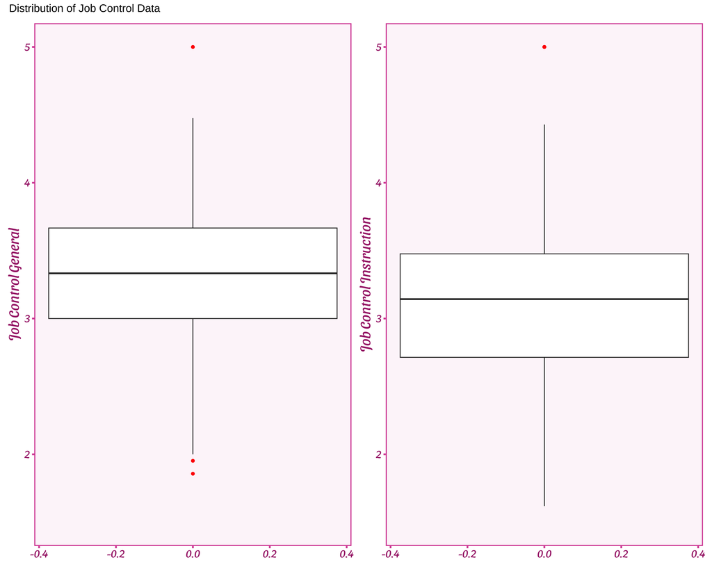

```r
p7 <- ggplot(d, aes(y=jobcontrol.general.score.1989)) +
  geom_boxplot(outlier.color = "red") +
  labs(y = "Job Control General") +
  coord_cartesian(ylim=c(1.5, 5)) +
  theme_barbie()

p8 <- ggplot(d, aes(y=jobcontrol.instruction.score.1989)) +
  geom_boxplot(outlier.color = "red") +
  labs(y = "Job Control Instruction") +
  coord_cartesian(ylim=c(1.5, 5)) +
  theme_barbie()

plots(p7, p8, title = "Distribution of Job Control Data")
```

### Hypothesis Testing

**Note**

Hypothesis testing is a method of statistics inference used to decide if the sample data provide enough evidence or support to draw conclusions about the population. For this study, I used t-tests and ANOVA to compare means.

**Student’s t-test** is a statistical test used to compare the means of two groups. A **paired t-test** compares means of two measurements taken from the same individual. For example, paired t-tests are frequently used for comparing pre- and post-test scores. In this case, the instruction and general job control scores are from the same group of people. **Analysis of Variance (ANOVA)** compares the means of multiple groups.

Two hypotheses are formulated: the null hypothesis (H0) that the difference between means is 0 and the alternative hypothesis (Ha) that the true mean difference is not equal to 0.

T-tests and ANOVA are parametric tests. One assumption of parametric tests is that the data are approximately normal. As demonstrated in the descriptive statistics above, the data are approximately normal.

**Tip**

If your data aren’t approximately normal, there are non-parametric tests that can be used. Instead of a paired t-test, Wilcoxon Signed Rank test, instead of unpaired t-test, Mann-Whitney U test, instead of ANOVA, Kruskal-Wallis H test.

UCLA OARC provides a [useful table to help you choose the correct statistical test](https://stats.oarc.ucla.edu/other/mult-pkg/whatstat/), and they provide links with directions for executing the tests in SAS, Stata, SPSS, and R.

For an example of a resent study that used non-parametric tests, see “[Complex and Varied: Factors Related to the Research Productivity of Academic Librarians in the United States](https://crl.acrl.org/index.php/crl/article/view/25876/33812).”

The paired t-test testing the difference between job control general and job control instruction suggests that the effect is positive, statistically significant, and medium (difference = 0.20, 95% CI [0.16, 0.25], t(244) = 8.29, p < .001; Cohen’s d = 0.53, 95% CI [0.40, 0.66]). The effect size is labeled following Cohen’s (1988) recommendations.

**Note**

The results of the paired t-test are reported above. P-values are frequently used to assess statistical significance and can carry significant weight. Generally, for research in LIS, a p-value less than 0.05 is significant. 0.05, 0.01, and 0.001 are frequently used thresholds.

In 2016, the American Statistical Association (ASA) released a [statement on p-values and statistical significance](https://doi.org/10.1080/00031305.2016.1154108). They informally defined a p-value as “the probability under a specified statistical model that a statistical summary of the data (e.g., the sample mean difference between two compared groups) would be equal to or more extreme than its observed value.” They note both that “p-values do not measure the probability that the studied hypothesis is true, or the probability that the data were produced by random chance alone” and that “scientific conclusions and business or policy decisions should not be based only on whether a p-value passes a specific threshold,” which is possibly to say that these thresholds are arbitrary.

In the same statement, the ASA notes that p-values don’t measure the size of an effect. As such, in my reporting of the results, I’ve included the effect size. For t-tests, the effect size is measured using Cohen’s d. Based on Cohen’s recommendations in his 1988 textbook, 0.5 is considered medium. The effect size measures the strength of the relationship between the variables.

Additionally, the 95% confidence intervals for the mean difference and Cohen’s d are reported. The confidence interval takes into account the size of the sample. There’s a 95% chance that the true value falls within the confidence interval. For example, there is a 95% chance that the true mean is between 0.16 and 0.25. For smaller samples, the confidence interval would be larger.

I included the code for the t-test in R below just to show how simple it is to run in R. Cohen’s d is also simple to calculate using the effectsize package from easystats. Click the arrow to unfold the code.

```r
t.test(d$jobcontrol.general.score.1989,
       d$jobcontrol.instruction.score.1989,
       paired = TRUE)
##
##  Paired t-test
##
## data:  d$jobcontrol.general.score.1989 and d$jobcontrol.instruction.score.1989
## t = 8.2908, df = 244, p-value = 7.593e-15
## alternative hypothesis: true mean difference is not equal to 0
## 95 percent confidence interval:
##  0.1552993 0.2520865
## sample estimates:
## mean difference
##       0.2036929

cohens_d(t.test(d$jobcontrol.general.score.1989,
                d$jobcontrol.instruction.score.1989,
                paired = TRUE))
## Cohen's d |       95% CI
## ------------------------
## 0.53      | [0.40, 0.66]
```

### Correlation and Linear Regression

**Note**

**Pearson’s product-moment correlation** is a measure of the strength of the linear correlation between two sets of data. The correlation coefficient (r) is a value between -1 and 1. Similarly to ANOVA and t-tests, Pearson’s product moment correlation is a parametric test. Spearman’s rank correlation is an alternative non-parametric measure of rank correlation.

**Linear regression** is a method of modeling the relationship between variables. The coefficient of determination (r-squared) is a measurement of the proportion of variance in the dependent variable that can be explained by the independent variable. The value of the coefficient is always between 0 and 1. The graphs below for the linear models include a 95% margin of error for the model, similar to the confidence intervals mentioned above.

Correlation measures the linear relationship between the variable and the linear regression allows us to predict the impact of the independent variable on the dependent variable. For example, job control in instruction predicts a moderate proportion of variance in work-related burnout. Hence, we can predict that academic instruction librarians with low job control in instruction will experience greater work-related burnout in comparison to colleagues with greater job control. Linear regression may be described as explanatory. However, as with correlation, causation is not implied or inferred.

The Pearson’s product-moment correlations between job control (instruction) and the three dimensions of burnout are as follows and as visualized in Figure 2:

- personal burnout: negative, statistically significant, and medium (r = -0.29, 95% CI [-0.40, -0.17], t(243) = -4.76, p < .001)
- work-related burnout: negative, statistically significant, and large (r = -0.36, 95% CI [-0.47, -0.25], t(243) = -6.10, p < .001)
- client-related burnout: negative, statistically significant, and large (r = -0.33, 95% CI [-0.44, -0.21], t(243) = -5.41, p < .001).

Figure 2: Correlation Matrix.

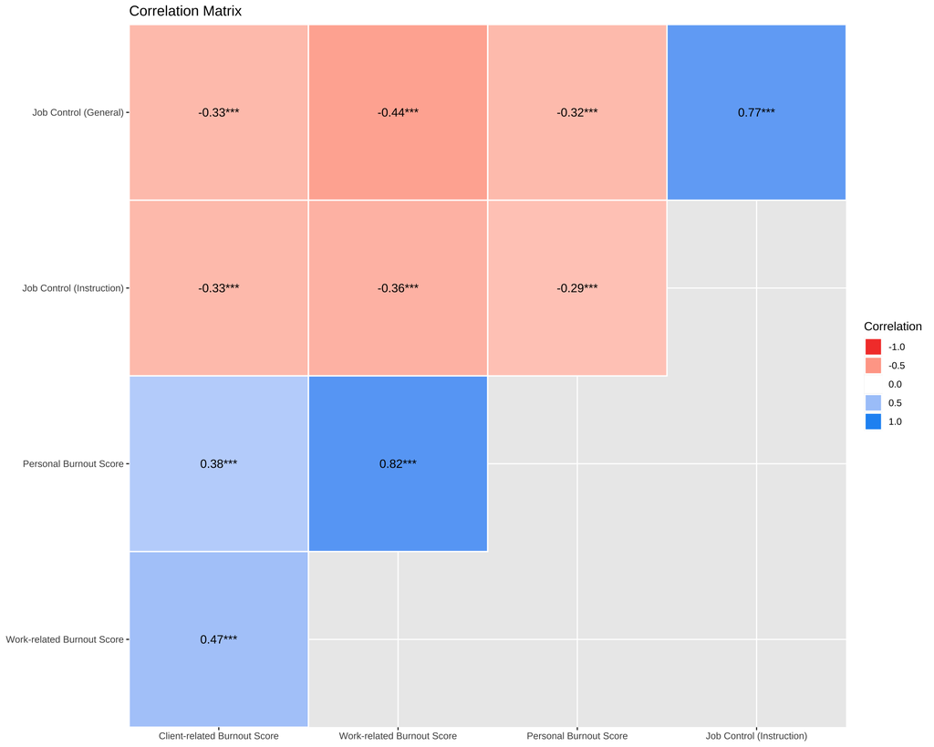

```r
correlation_matrix <- correlation(d, select=c("jobcontrol.general.score.1989","jobcontrol.instruction.score.1989", "TPBS", "TWRBS", "TCRBS"), rename = c("Job Control (General)","Job Control (Instruction)", "Personal Burnout Score", "Work-related Burnout Score", "Client-related Burnout Score"))
correlation_matrix |>
  summary(redundant = FALSE) |>
  plot(cex=50)
```

Linear models (estimated using OLS) were fitted to predict TWRBS (Figure 3), TPBS (Figure 4), and TCRBS (Figure 5) with job control when completing instructional responsibilities:

- TWRBS ~ Job Control (Instruction): The model explains a statistically significant and moderate proportion of variance (R2 = 0.13, F(1, 243) = 37.22, p < .001, adj. R2 = 0.13). The model's intercept, corresponding to Job Control (Instruction) = 0, is at 86.96 (95% CI [74.77, 99.15], t(243) = 14.05, p < .001). Within this model, the effect of Job Control (Instruction) is statistically significant and negative (beta = -11.85, 95% CI [-15.67, -8.02], t(243) = -6.10, p < .001; Std. beta = -0.36, 95% CI [-0.48, -0.25]). The model is shown in Figure 3 along with the linear model to predict TWRBS with Job Control (General).

Figure 3: Correlation between Work-related Burnout and Job Control.

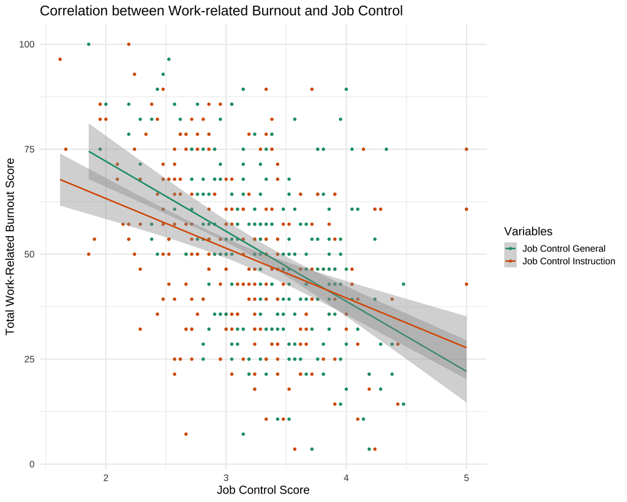

```r
controlxinstruction <- data.frame(d$jobcontrol.general.score.1989, d$jobcontrol.instruction.score.1989, d$TWRBS, d$TPBS, d$TCRBS)
controlxinstruction <- tidyr::pivot_longer(controlxinstruction, cols = c('d.jobcontrol.general.score.1989', 'd.jobcontrol.instruction.score.1989'), names_to = 'variable', values_to = 'value')

ggplot(controlxinstruction, aes(x=value, y=d.TWRBS, color=variable)) +
  geom_point() +
  geom_smooth(method="lm") +
  labs(title = "Correlation between Work-related Burnout and Job Control",
       x = "Job Control Score",
       y = "Total Work-Related Burnout Score") +
  scale_color_brewer(palette="Dark2", name = "Variables", labels = c("Job Control General", "Job Control Instruction")) +
  theme_minimal(base_size = 16)
```

- TPBS ~ Job Control (Instruction): The model explains a statistically significant and weak proportion of variance (R2 = 0.09, F(1, 243) = 22.61, p < .001, adj. R2 = 0.08). The model's intercept, corresponding to Job Control (Instruction) = 0, is at 85.16 (95% CI [73.27, 97.04], t(243) = 14.11, p < .001). Within this model, the effect of Job Control (Instruction) is statistically significant and negative (beta = -9.00, 95% CI [-12.73, -5.27], t(243) = -4.76, p < .001; Std. beta = -0.29, 95% CI [-0.41, -0.17]). The model is shown in Figure 4 along with the linear model to predict TPBS with Job Control (General).

Figure 4: Correlation between Personal Burnout and Job Control.

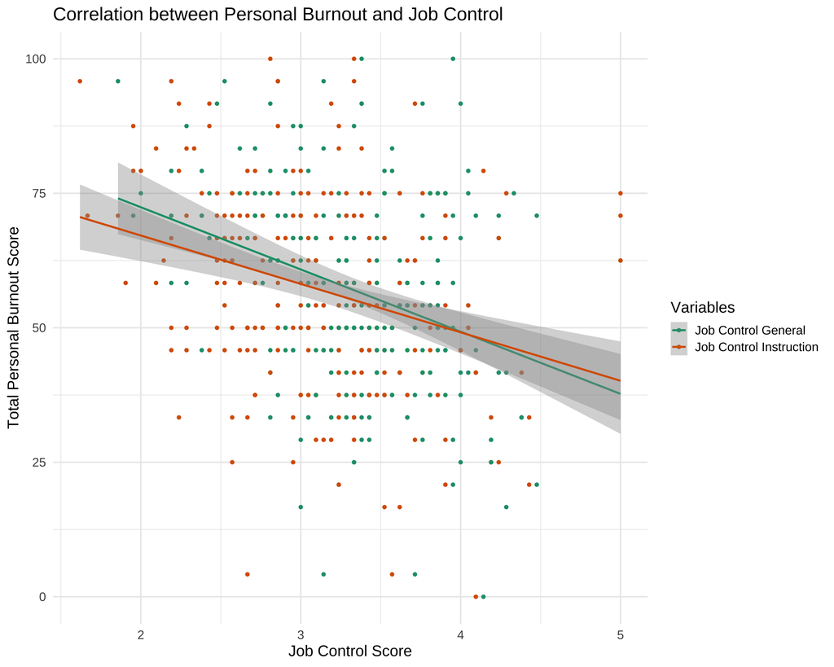

```r
ggplot(controlxinstruction, aes(x=value, y=d.TPBS, color=variable)) +
  geom_point() +
  geom_smooth(method="lm") +
  labs(title = "Correlation between Personal Burnout and Job Control",
       x = "Job Control Score",
       y = "Total Personal Burnout Score") +
  scale_color_brewer(palette="Dark2", name = "Variables", labels = c("Job Control General", "Job Control Instruction")) +
  theme_minimal(base_size = 16)
```

- TCRBS ~ Job Control (Instruction): The model explains a statistically significant and weak proportion of variance (R2 = 0.11, F(1, 243) = 29.23, p < .001, adj. R2 = 0.10). The model's intercept, corresponding to Job Control (Instruction) = 0, is at 63.41 (95% CI [50.52, 76.30], t(243) = 9.69, p < .001). Within this model, the effect of Job Control (Instruction) is statistically significant and negative (beta = -11.10, 95% CI [-15.15, -7.06], t(243) = -5.41, p < .001; Std. beta = -0.33, 95% CI [-0.45, -0.21]). The model is shown in Figure 5 along with the linear model to predict TCRBS with Job Control (General).

Figure 5: Correlation between Client-Related Burnout and Job Control.

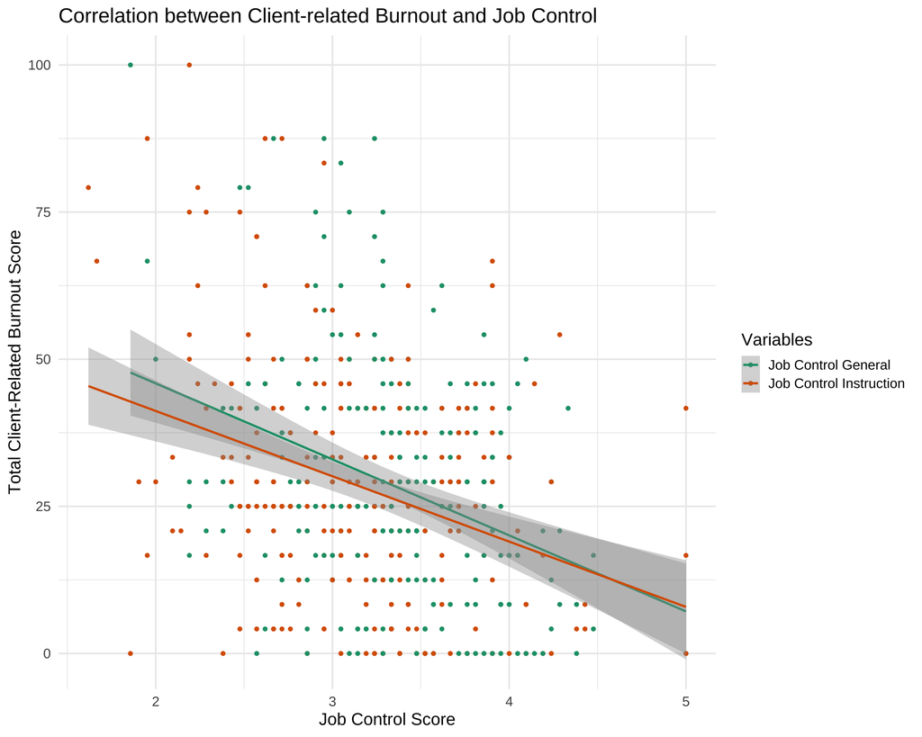

```r
ggplot(controlxinstruction, aes(x=value, y=d.TCRBS, color=variable)) +
  geom_point() +
  geom_smooth(method="lm") +
  labs(title = "Correlation between Client-related Burnout and Job Control",
       x = "Job Control Score",
       y = "Total Client-Related Burnout Score") +
  scale_color_brewer(palette="Dark2", name = "Variables", labels = c("Job Control General", "Job Control Instruction")) +
  theme_minimal(base_size = 16)
```

Standardized parameters were obtained by fitting the models on a standardized version of the dataset. 95% Confidence Intervals (CIs) and p-values were computed using a Wald t-distribution approximation.

While the R2 for all of the above models using job control for instruction are lower than found in Johnson (2023) using job control in general, which suggests that job control for instruction explains a weaker proportion of variance, the data still suggest some impact of job control on burnout. Since burnout is a multi-faceted phenomenon, it makes sense that job control wouldn't be a sole predictor of burnout.

### Analysis of Variance

**Note**

We have finally arrived at the analysis of variance (ANOVA) mentioned back when I mentioned t-tests. Analysis of variance can compare means across multiple groups. In this case, ANOVA tests were used for all of the demographic and job characteristic data collected in the study as the goal is to compare the means across multiple groups (e.g., among people of different genders, different income levels, etc.).

While one-way ANOVA can test the difference between multiple groups, **Tukey’s HSD** can be used for post-hoc or follow up analysis test for statistically significant differences between pairs of group means.

In addition to the hypothesis testing, column charts visually demonstrate the variance between means. Each column chart below includes error bars showing a 95% confidence interval. The error bars are responsive to sample size and can be another effective measure of the significance of results beyond the p-value.

```r
attributes <- c("Gender", "Gender Modality","Disability", "Income", "Time at Institution", "Time Since Degree", "Time in Libraries", "Public or Private", "Non-profit or For-profit", "Permanent or Temporary", "Full-time or Part-time", "Staff or Faculty", "Tenure (individual)", "Tenure (institution)", "Union", "Training Received", "Training Quality", "Teaching Workload")

values <- c(0.572, 0.192, 0.822, 0.104, "0.0583 *", "0.0263 **", 0.195, 0.406, 0.858, 0.187, "0.0934 *", 0.238, "0.0845 *", 0.215, 0.972, "0.0357 **", 0.814, 0.11)

table <- cbind(attributes, values)
colnames(table) <- c("Attribute", "p-value")
kable(table)
```

Table 2: P-values from ANOVA tests of attributes studied (* denotes p < 0.1 and ** denotes p < 0.05).

| Attribute | p-value |
| --- | --- |
| Gender | 0.572 |
| Gender Modality | 0.192 |
| Disability | 0.822 |
| Income | 0.104 |
| Time at Institution | 0.0583 * |
| Time Since Degree | 0.0263 ** |
| Time in Libraries | 0.195 |
| Public or Private | 0.406 |
| Non-profit or For-profit | 0.858 |
| Permanent or Temporary | 0.187 |
| Full-time or Part-time | 0.0934 * |
| Staff or Faculty | 0.238 |
| Tenure (individual) | 0.0845 * |
| Tenure (institution) | 0.215 |
| Union | 0.972 |
| Training Received | 0.0357 ** |
| Training Quality | 0.814 |
| Teaching Workload | 0.11 |

```r
d |>
  group_by(time.institution) |>
  summarize(N = n(),
            Mean = mean(jobcontrol.instruction.score.1989),
            Median = median(jobcontrol.instruction.score.1989),
            "Std. Dev." = sd(jobcontrol.instruction.score.1989),
            Min = min(jobcontrol.instruction.score.1989),
            Max = max(jobcontrol.instruction.score.1989)) |>
  kable(col.names = c("Time at Institution", "N", "Mean", "Median", "Std. Dev.", "Min.", "Max."), digits = 2)
```

| Time at Institution | N | Mean | Median | Std. Dev. | Min. | Max. |
| --- | --- | --- | --- | --- | --- | --- |
| Less than 1 | 31 | 3.11 | 3.05 | 0.59 | 1.86 | 5.00 |
| 1 to 5 | 100 | 3.02 | 3.02 | 0.61 | 1.62 | 5.00 |
| 6 to 10 | 55 | 3.16 | 3.24 | 0.57 | 1.90 | 5.00 |
| 11 to 15 | 23 | 3.22 | 3.19 | 0.58 | 2.24 | 4.38 |
| 16 or more | 36 | 3.35 | 3.40 | 0.58 | 2.19 | 4.29 |

```r
TukeyHSD(aov(jobcontrol.instruction.score.1989 ~ time.institution, data = d)) |>
  broom::tidy() |>
  select(-term, -null.value) |>
  kable(col.names = c("Paired Groups", "Difference", "CI Low", "CI High", "p-value"),digits = 2)
```

| Paired Groups | Difference | CI Low | CI High | p-value |
| --- | --- | --- | --- | --- |
| 1 to 5-Less than 1 | -0.09 | -0.42 | 0.24 | 0.95 |
| 6 to 10-Less than 1 | 0.05 | -0.31 | 0.42 | 0.99 |
| 11 to 15-Less than 1 | 0.11 | -0.33 | 0.56 | 0.96 |
| 16 or more-Less than 1 | 0.24 | -0.16 | 0.64 | 0.46 |
| 6 to 10-1 to 5 | 0.14 | -0.13 | 0.41 | 0.61 |
| 11 to 15-1 to 5 | 0.20 | -0.17 | 0.58 | 0.57 |
| 16 or more-1 to 5 | 0.33 | 0.01 | 0.65 | 0.04 |
| 11 to 15-6 to 10 | 0.06 | -0.34 | 0.47 | 0.99 |
| 16 or more-6 to 10 | 0.19 | -0.16 | 0.54 | 0.57 |
| 16 or more-11 to 15 | 0.13 | -0.31 | 0.56 | 0.93 |

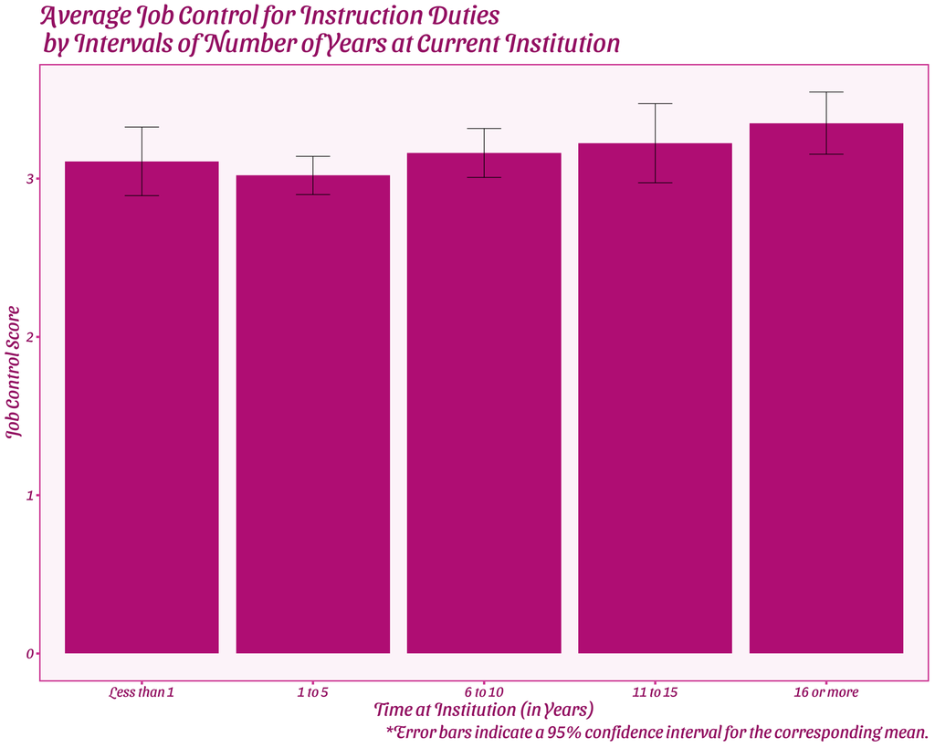

```r
Control_instruction_timeatinstitution_means <- data.frame(d %>%
                                                          group_by(time.institution) %>%
                                                          summarise_at(vars(jobcontrol.instruction.score.1989), list(name=mean)))

tempdf <- d %>%
  group_by(time.institution) %>%
  summarize(N = n(),
            Mean = mean(jobcontrol.instruction.score.1989),
            Median = median(jobcontrol.instruction.score.1989),
            "Std. Dev." = sd(jobcontrol.instruction.score.1989),
            CI = qt(0.975, df=n()-1)*sd(jobcontrol.instruction.score.1989)/sqrt(n()),
            CI_low = mean(jobcontrol.instruction.score.1989)-CI,
            CI_hi = mean(jobcontrol.instruction.score.1989)+CI,
            Min = min(jobcontrol.instruction.score.1989),
            Max = max(jobcontrol.instruction.score.1989))

Control_instruction_timeatinstitution_means$CI_low <- tempdf$CI_low
Control_instruction_timeatinstitution_means$CI_hi <- tempdf$CI_hi
Control_instruction_timeatinstitution_means$time.institution <- factor(Control_instruction_timeatinstitution_means$time.institution, levels = c("Less than 1", "1 to 5", "6 to 10", "11 to 15", "16 or more"))
Control_instruction_timeatinstitution_means <- Control_instruction_timeatinstitution_means[-6,]

ggplot(Control_instruction_timeatinstitution_means, aes(x=time.institution, y=name)) +
  geom_col(fill = barbie_theme_colors["dark"]) +
  geom_errorbar(aes(ymin=CI_low, ymax=CI_hi),
                linewidth=.3,
                width=.2,
                position=position_dodge(.9)) +
  labs(x="Time at Institution (in Years)", y="Job Control Score", title="Average Job Control for Instruction Duties \n by Intervals of Number of Years at Current Institution", caption = "*Error bars indicate a 95% confidence interval for the corresponding mean.") +
  theme_barbie()
```

#### Training Received

As demonstrated in Table 5 and Figure 7, mean job control for instruction is higher for those who have received training for library instruction than those who haven't; however, job control for instruction is particularly high for those who responded "Other." Responses for other generally referenced teacher training that was not specific to libraries or not provided through a library program.

```r
d |>
  group_by(Training3) |>
  summarize(N = n(),
            Mean = mean(jobcontrol.instruction.score.1989),
            Median = median(jobcontrol.instruction.score.1989),
            "Std. Dev." = sd(jobcontrol.instruction.score.1989),
            Min = min(jobcontrol.instruction.score.1989),
            Max = max(jobcontrol.instruction.score.1989)) |>
    kable(col.names = c("Training Received", "N", "Mean", "Median", "Std. Dev.", "Min.", "Max."), digits = 2)
```

Table 5: Job control for instruction by whether or not training was received.

| Training Received | N | Mean | Median | Std. Dev. | Min. | Max. |
| --- | --- | --- | --- | --- | --- | --- |
| Yes | 173 | 3.14 | 3.14 | 0.61 | 1.86 | 5.00 |
| No | 58 | 3.02 | 3.00 | 0.57 | 1.62 | 4.29 |
| Other | 14 | 3.47 | 3.40 | 0.43 | 2.71 | 4.10 |

| Paired Groups | Difference | CI Low | CI High | p-value |
| --- | --- | --- | --- | --- |
| No-Yes | -0.13 | -0.34 | 0.08 | 0.34 |
| Other-Yes | 0.32 | -0.06 | 0.71 | 0.12 |
| Other-No | 0.45 | 0.03 | 0.87 | 0.03 |

Figure 7: Average job control for instruction duties by whether or not participant received training.

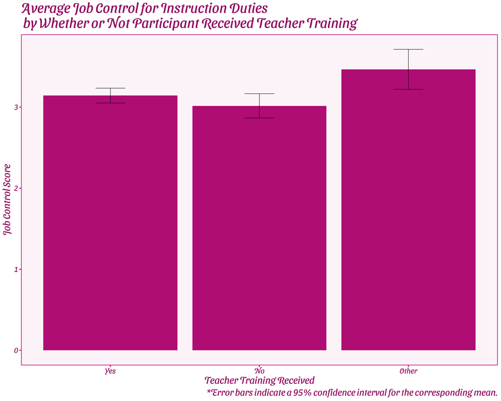

```r
Control_instruction_Training_means <- data.frame(d %>%
                                     group_by(Training3) %>%
                                     summarise_at(vars(jobcontrol.instruction.score.1989), list(name=mean)))

tempdf <- d %>%
  group_by(Training3) %>%
  summarize(N = n(),
            Mean = mean(jobcontrol.instruction.score.1989),
            Median = median(jobcontrol.instruction.score.1989),
            "Std. Dev." = sd(jobcontrol.instruction.score.1989),
            CI = qt(0.975, df=n()-1)*sd(jobcontrol.instruction.score.1989)/sqrt(n()),
            CI_low = mean(jobcontrol.instruction.score.1989)-CI,
            CI_hi = mean(jobcontrol.instruction.score.1989)+CI,
            Min = min(jobcontrol.instruction.score.1989),
            Max = max(jobcontrol.instruction.score.1989))

Control_instruction_Training_means$CI_low <- tempdf$CI_low
Control_instruction_Training_means$CI_hi <- tempdf$CI_hi
Control_instruction_Training_means$Training3 <- factor(Control_instruction_Training_means$Training3, levels = c("Yes", "No", "Other"))

ggplot(Control_instruction_Training_means, aes(x=Training3, y=name)) +
  geom_col(fill = barbie_theme_colors["dark"]) +
  geom_errorbar(aes(ymin=CI_low, ymax=CI_hi),
                linewidth=.3,
                width=.2,
                position=position_dodge(.9)) +
  labs(x="Teacher Training Received", y="Job Control Score", title="Average Job Control for Instruction Duties \n by Whether or Not Participant Received Teacher Training", caption = "*Error bars indicate a 95% confidence interval for the corresponding mean.") +
  theme_barbie()
```